# 00_probabilidad

[figure not shown]

Profesora Carolina Luque

**Resultado de aprendizaje:** Analiza datos de diversa índole mediante técnicas de estadística descriptiva y probabilidad.

**Hito 2:** Probabilidad.

**Temas:**

- Conceptos previos.
- Probabilidad.
- Propiedades.
- Probabilidad condicional.
- Probabilidad total.
- Teorema de Bayes.
- Probabilidades en ciencia de datos.

# **Conceptos previos**

## **Experimento aleatorio y espacio muestral**

Un **experimento aleatorio** es cualquier experimento (fenómeno) que satisface las siguientes condiciones:

- Todos los posibles resultados del experimento son conocidos antes de ejecutarlo (o que suceda).
- El resultado de cualquier ejecución del experimento no se puede conocer de antemano.
- El experimento se puede repetir (suceder) bajo las mismas condiciones.

Son ejemplos de experimentos aleatorios

- *Seleccionar una muestra aleatoria de clientes para implementar una encuesta sobre la calidad del servicio*. El resultado de la encuesta es incierto y puede variar entre diferentes encuestados.
- *Lanzar un nuevo producto al mercado*. Aunque se realicen estudios de mercado y estrategias de marketing previas, el resultado del lanzamiento es incierto. Existen muchas variables que pueden influir en el éxito o fracaso del producto, y no es posible predecir con certeza cómo reaccionarán los consumidores o cómo se desarrollará el mercado.

Al conjunto de todos los resultados posibles de un experimento estadístico (aleatorio) se le llama **espacio muestral** y se representa con el símbolo $\Omega$.

## **Teoría de conjuntos**

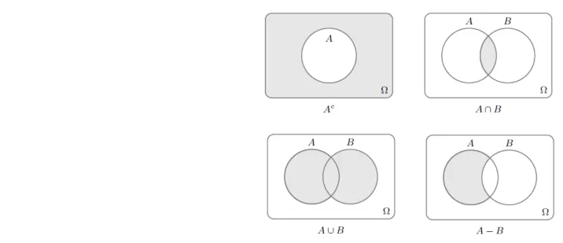

Sea $\Omega$ el conjunto universal con $A \subseteq \Omega$ y $B \subseteq \Omega$.

- Un **evento $A$** es un subconjunto del espacio muestral. Es decir, $A \subseteq \Omega$
- El **complemento de un evento $A$** respecto de $\Omega$ es el subconjunto de todos los elementos de $\Omega$ que no están en $A$. Denotamos el complemento de $A$ mediante el símbolo $A'$ o $A^{c}$.

$$A^c=\left\lbrace x\in\Omega:x\notin A\right\rbrace$$

- La **intersección de dos eventos $A$ y $B$**, se denota como $A \cap B$ y es el evento que contiene todos los elementos que son comunes a $A$ y a $B$.

$$A\cap B=\left\lbrace x\in\Omega:x\in A\text{ y }x\in B\right\rbrace$$

- Dos eventos $A$ y $B$ son **mutuamente excluyentes o disjuntos** si $A \cap B = \emptyset$. Es decir, $A$ y $B$ no tienen elementos en común. Esto es, no pueden ocurrir de manera simultánea.
- La **unión de dos eventos $A$ y $B$**, se denota como $A \cup B$. Es el evento que contiene todos los elementos que pertenecen a $A$ o a $B$, o a ambos.

$$A\cup B=\left\lbrace x\in\Omega:x\in A\text{ o }x\in B\right\rbrace$$

- La **diferencia entre $A$ y $B$**, se denota como $A - B$. Es el evento que contiene todos los elementos que pertenecen a $A$ y no estan en $B$.

$$A-B=\left\lbrace x\in\Omega:x\in A\text{ y }x\notin B\right\rbrace$$

- La **diferencia simétrica entre $A$ y $B$**, se denota como $A △ B$.

$$A \triangle B= (A - B) \cup (B-A) $$

- Las **leyes de Morgan** corresponden a los siguientes eventos

$$(A\cup B)^c=A^c\cap B^c$$$$(A\cap B)^c=A^c\cup B^c$$

# **Probabilidad**

## **Medida de probabilidad**

Una medida de probabilidad, $P$, es una **función** que asigna a cada evento $A$ de un experimento aleatorio un valor numérico entre $0$ y $1$.

$$ A\longrightarrow P(A) $$

Luego, la **probabilidad de un evento** $A$ es una medida de la **incertidumbre** relacionada con la posibilidad de la ocurrencia del evento $A$.

Esta función que cumple con las siguientes propiedades:

- $P(A)\geq0$.
- $P(\Omega)=1$.
- Si $\{A_i\}_{i=1}^{\infty}$ es una secuencia de **eventos disjuntos** o **eventos mutuamente excluyentes** incluidos en $\Omega$, es decir, $A_i \cap A_j = \emptyset$ para $i \neq j$, entonces

$$ P\left(\bigcup_{i=1}^{\infty}A_i \right)=\sum_{i=1}^{\infty}P(A_i)\,. $$

## **Enfoques para el cálculo de probabilidades**

Existen tres enfoques fundamentales para el cálculo o asignación de probabilidades: **Laplaciano**, **frecuentista** y el **subjetivo**.

### **Enfoque Laplaceano**

Este enfoque asume que todos los eventos simples de un experimento aleatorio son equiprobables (igualemnte probables). La probabilidad de que ocurra un evento $A$ se calcula como la razón entre el número de resultados favorables a $A$ que se denota como $|A|$ y el número total de resultados posibles en el espacio muestral $\Omega$ que se denota como $|\Omega|$. Esto es

$$ P(A) = \frac{|A|}{|\Omega|} $$

**Caso**

*Nos ''encontramos'' una tarjeta de débito al lado de un cajero automático. Si la introducimos en el cajero, disponemos de tres intentos para acertar con la clave de 4 digitos ¿cuál es la probabilidad de acertar?*

### **Enfoque frecuentista**

La probabilidad se define como el límite de la frecuencia relativa de la ocurrencia de un evento después de un número grande de repeticiones del experimento aleatorio. Formalmente, si $n$ es el número total de repeticiones del experimento y $n_A$ es el número de veces que ocurre el evento $A$, entonces la probabilidad de $A$ se aproxima mediante:

$$ P(A) = \lim_{n \to \infty} \frac{n_A}{n} $$

- Este enfoque se basa en observaciones repetidas y no asume que los resultados son equiprobables.
- Cuanto mayor sea el número de repeticiones del experimento, tanto mejor será la estimación de la probabilidad.
- La validez del cálculo depende de que las condiciones bajo las que se realice el experimento sean semejantes.

NOTA: Ejecutar esta simulación en R

```
library(animation)
flip.coin(faces = 6,prob=rep(1/6,6),border="white",grid = "white",
col = 1:6,type = "p", pch = 21, bg = "transparent", digits = 3)
```

**Caso**

*Cuando observamos un número elevado de pacientes con síntomas específicos, podemos estimar la probabilidad de que estos pacientes padezcan una determinada enfermedad. En cada análisis, un paciente puede o no tener la enfermedad. Al registrar el número de pacientes que efectivamente tienen la enfermedad ($k$) de un total de $n$ pacientes, la frecuencia relativa de la enfermedad es $\frac{k}{n}$. A medida que el número total de pacientes $n$ aumenta, esta frecuencia relativa se aproxima a un valor numérico estable, que representa la probabilidad de tener la enfermedad.*

### **Enfoque subjetivo**

La probabilidad se interpreta como el estado de información que tiene el investigador sobre la ocurrencia de un evento. El estado de información depende de la información disponible y el juicio subjetivo.

# **Propiedades**

Dado un experimento aleatorio que tiene asociado un espacio muestral ($\Omega$) no vacío, $A$ y $B$ eventos aleatorios incluidos en $\Omega$ y $P(\cdot)$ una medida de probabilidad sobre $\Omega$. Entonces se satisface que:

- $P(\Phi) = 0$, $\Phi$ es un evento imposible.
- $P(A')=1- P(A)$.
- $P(A-B)=P(A)-P(A\cap B)$.
- $P(A \cup B) = P(A) + P(B) - P(A \cap B)$.
- En términos generales, sean $A_1,\ldots,A_m$ eventos aleatorios incluidos en un espacio muestral $\Omega$. Entonces

$$ P\left(\bigcup_{i=1}^{m} A_i\right)=\sum_{i=1}^{m}P(A_i)-\sum_{i<j}P(A_i\cap A_j)+\sum_{i<j<k}P(A_i\cap A_j\cap A_k)-\ldots-(-1)^{m-1}P\left(\bigcap_{i=1}^{m} A_i \right)\,. $$

En particular, para $m=3$:

$$ P(A_1\cup A_2\cup A_3)=P(A_1)+P(A_2)+P(A_3)-P(A_1\cap A_2)-P(A_1\cap A_3)-P(A_2\cap A_3)+P(A_1\cap A_2\cap A_3)\,. $$

**Ejemplo**: En el último trimestre, se ha realizado la siguiente clasificación de pacientes de una clínica en función de tener o no artrosis.

|  | Artrosis | No Artrosis | Totales |
| --- | --- | --- | --- |
| Hombres | 45 | 30 | 75 |
| Mujeres | 55 | 15 | 70 |
| Totales | 100 | 45 | 145 |

- La probabilidad de que un paciente tenga artrosis es:

$ P(A) = \frac{100}{145} \approx 0.69 $

- La probabilidad de que un paciente **no** tenga artrosis es:

$ P(A^{c}) = 1 - \frac{100}{145} \approx 0.31 $

- La probabilidad de que un paciente tenga artrosis **o** sea una mujer es:

$ P(A \cup M) = P(A) + P(M) - P(A \cap M) = \frac{100}{145} + \frac{70}{145} - \frac{55}{145} \approx 0.79 $

- La probabilidad de que un paciente sea hombre **y** **no** tenga artrosis es:

$ P(H \cap A^{c}) = P(H-A)=P(H) - P(H \cap A) = \frac{75}{145} - \frac{45}{145} = \frac{30}{145} \approx 0.21 $

# **Probabilidad condicional**

Sean $A$ y $B$ eventos aleatorios incluidos en un espacio muestral no vacío $\Omega$ y $P(\cdot)$ una medida de probabilidad sobre $\Omega$.

La **probabilidad condicional** es una medida de probabilidad definida por:

$$ P(A\mid B)=\frac{P(A\cap B)}{P(B)} $$

siempre que $P(B) > 0$.

$P(A\mid B)$ se lee como *la probabilidad de que ocurra un evento $A$ dado el evento $B$*.

## **Regla multiplicativa**

De lo anterior se se satisface que:

$$ P(A\cap B)=P(A\mid B)\,P(B) $$

Además, si $A$ y $B$ son eventos **independientes**, es decir, si $A$ y $B$ son eventos tales que $P(A\mid B) = P(A)$, entonces:

$$ P(A\cap B)=P(A)\,P(B)\,. $$

**Ejemplo**: En el último trimestre, se ha realizado la siguiente clasificación de pacientes de una clínica en función de tener o no artrosis.

|  | Artrosis | No Artrosis | Totales |
| --- | --- | --- | --- |
| Hombres | 45 | 30 | 75 |
| Mujeres | 55 | 15 | 70 |
| Totales | 100 | 45 | 145 |

- Si entra en la consulta una mujer, ¿cuál es la probabilidad de que tenga artrosis?

Esta probabilidad condicionada se denota como $P(A \mid M)$ y se calcula así:

$$ P(A \mid M) = \frac{P(A \cap M)}{P(M)} = \frac{\frac{55}{145}}{\frac{70}{145}}=\frac{55}{70} $$

$$ P(A \mid M) = \frac{55}{70} \quad \text{y} \quad P(A)=\frac{100}{145} $$

$A$ y $M$ no son eventos independientes. La presencia de una condición influye en la ocurrencia de la otra.

# **Probabilidad total**

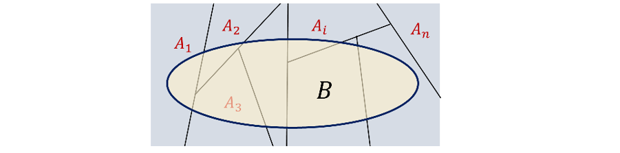

Sea $\{A_i\}_{i=1}^{m}$ una partición de un espacio muestral no vacío $\Omega$, es decir, $A_1, A_2,\ldots, A_m$ es una colección de subconjuntos de $\Omega$ tales que:

$$ \bigcup_{i=1}^m A_i=\Omega \qquad\text{y}\qquad A_i\cap A_j=\Phi\,,\,\text{para }i\neq j\,. $$

Entonces, la probabilidad de un evento $B$ se puede calcular como:

$$ P(B) = \sum_{j=1}^{m} P(B\mid A_j)\,P(A_j)\,. $$

**Ejemplo**: La tienda online favorita del 33% de los socios de un foro de tecnología es Pccomponendas, un 8% prefiere Medianamart, el 2% prefiere Evoy y el resto prefiere comprar en Amazon. La probabilidad de que el pedido se pierda y no llegue al destinatario, según la tienda que lo envíe, es 0.8, 0.9, 0.7 y 0.6, respectivamente. Pepe, miembro del foro desde 2003, ha pedido el último modelo de linterna. Si acaba de entrar al foro y el primer hilo que abre es para quejarse del foro, ¿cuál es la probabilidad de que este molesto porque no ha recibido el envío?

**Solución**

- $A_1 =$ ''pedido a Pccomponendas'',
- $A_2 =$ ''pedido a Medianamart'',
- $A_3 =$ ''pedido a Evoy'',
- $A_4 =$ ''pedido a Amazon'',

y

- $B =$ ''el pedido no llega a tiempo''.

Se tiene que

\begin{align*} P(A_1) &= 0.33, \\ P(A_2) &= 0.08, \\ P(A_3) &= 0.02, \\ P(A_4) &= 0.57. \end{align*}

Los sucesos $A_1$, $A_2$, $A_3$ y $A_4$ son mutuamente excluyentes y sus probabilidades suman 1, es decir, estos eventos son una partición del espacio muestral.

Además,

\begin{align*} P(B \mid A_1) &= 0.8, \\ P(B \mid A_2) &= 0.9, \\ P(B \mid A_3) &= 0.7, \\ P(B \mid A_4) &= 0.6. \end{align*}

Luego, la probabilidad de que el pedido no se haya recibido se puede calcular como una probabilidad total

\begin{align*} P(B) &= P(B \mid A_1) \cdot P(A_1) + P(B \mid A_2) \cdot P(A_2) \\ &\quad + P(B \mid A_3) \cdot P(A_3) + P(B \mid A_4) \cdot P(A_4) \\ &= 0.8 \cdot 0.33 + 0.9 \cdot 0.08 + 0.7 \cdot 0.02 + 0.6 \cdot 0.57 \\ &= 0.692. \end{align*}

La probabilidad de que Pepe no haya recibido el envío es de $69.2%$. Por lo tanto, es muy probable que este enfadado porque no recibió el pedido.

# **Teorema de Bayes**

Sea $\{A_i\}_{i=1}^{m}$ una partición de un espacio muestral no vacío $\Omega$. Entonces, la probabilidad de $A_k$, para $k=1,\ldots,m$, dado un evento $B$ se puede calcular como:

$$ P(A_k\mid B)=\frac{P(B\mid A_k)P(A_k)}{\sum_{j=1}^{m}P(B\mid A_j)\,P(A_j)}\,. $$

**Caso**

*Los síntomas de un paciente (cara amarilla) pueden ser provocados por diferentes causas (anemia, virus, entre otros). Cuando se presentan los síntomas, es de interes saber la probabilidad de que haya sido por una u otra causa.*

**Ejemplo**: La interacción en el foro permite confirmar que Pepe no recibio el pedido. Sin embargo, aún no refiere a la tienda ¿cuál de las tiendas online referidas en el foro tiene la mayor probabilidad de no haber realizado la entrega?

**Solución**

\begin{align*} P(A_i \mid B) &= \frac{P(B \mid A_i) \cdot P(A_i)}{P(B)}, \quad \text{para } i = 1, 2, 3, 4. \end{align*}\begin{align*} P(A_1 \mid B) &= \frac{P(B \mid A_1) \cdot P(A_1)}{P(B)} = \frac{0.8 \cdot 0.33}{0.692} \approx 0.380, \\ P(A_2 \mid B) &= \frac{P(B \mid A_2) \cdot P(A_2)}{P(B)} = \frac{0.9 \cdot 0.08}{0.692} \approx 0.104, \\ P(A_3 \mid B) &= \frac{P(B \mid A_3) \cdot P(A_3)}{P(B)} = \frac{0.7 \cdot 0.02}{0.692} \approx 0.020, \\ P(A_4 \mid B) &= \frac{P(B \mid A_4) \cdot P(A_4)}{P(B)} = \frac{0.6 \cdot 0.57}{0.692} \approx 0.496. \end{align*}

Por lo tanto, la tienda online con la mayor probabilidad de no haber realizado la entrega es **Amazon** con una probabilidad de aproximadamente $0.496$.

# **Probabilidades en ciencia de datos**

Ver el video [Detector de spam](https://www.youtube.com/watch?v=De2gX2rWGbs) para comprender la relación entre el Teorema de Bayes y clasificador de Bayes ingenuo (Naive Bayes)

# **Práctica 1. Cálculo de probabilidades**

Dirijase al aula virtual

1. Decargue el archivo **01_prac1-prop.ipynb**
2. Guarde los archivos en su lugar de trabajo

# **Referencias**

- Rajagopalan, G. (2021). A Python Data Analyst's Toolkit: Learn Python and Python-based Libraries with Applications in Data Analysis and Statistics. Springer.
- Igual, L. and Seguí, S. (2017). Introduction to Data Science A Python Approach to Concepts, Techniques and Applications. Springer.
- Haslwanter, T. (2016). An Introduction to Statistics with Python With Applications in the Life Sciences. Springer.